# Combined potato phylogeny

Kirk Amundson

2021_0301

Aim: Build a phylogeny using array-genotyped European potato clones from [Sharma et al (2018) G3](https://academic.oup.com/g3journal/article/8/10/3185/6026984?login=true), [Hirsch et al (2013) G3](https://www.g3journal.org/content/3/6/1003), sequencing data from [Hardigan et al (2017) PNAS](https://www.pnas.org/content/114/46/E9999), Li et al (2018) Mol Plant, and my resequencing of Desiree clones. Main question: Is USDA Desiree another clone represented in any of these panels?

## Packages:

```r
library(tidyverse)
library(viridis)
library(readxl)
library(ape)
library(phangorn)
```

## Functions:

```r
# extract all unique characters from a string, can be vectorized across a tibble column
uniqchars <- function(x) strsplit(x, "") %>% map(unique) %>% map(paste, collapse = "") %>% as_vector()
# separate a string of unique characters into columns. Fill NA from right
uniq_as_cols <- function(x) str_replace(x, "(^[A-Z])", "\\1:") %>%
  separate(x, into=paste0("allele_", 1:2), remove = F, fill = "right") %>%
  mutate(solcap_allele_2 = ifelse(solcap_allele_2 == "", NA, solcap_allele_2))
sep <- function(...) {
  dots <- list(...)
  separate_(..., into = paste(dots[[2]], attributes, sep = "_"), convert = T, sep = ":")
}
rc <- function(mystr) {
  # print(mystr)
  # tmp <- chartr("acgtACGT", "tgcaTGCA", mystr)
  tmp <- str_replace_all(mystr, c("A" = "T", "T" = "A", "G" = "C", "C" = "G"))
  splits <- strsplit(tmp, "")[[1]]
  # print(splits)
  reversed <- rev(splits)
  # print(reversed)
  out <- paste(reversed, collapse = "")
  return(out)
}
```

## Explore Sharma et al (2018) dataset: SNP array genotypes of 351 clones, primarily of European origin

```r
euro_snp <- read_excel("~/Downloads/Table S10.xlsx", col_names = T, sheet = 1, na = "-9") %>%
  mutate(study = "euro") %>%
  select(study, Name, everything()) %>%
  pivot_longer(-c(study, Name), names_to = "SNP", values_to = "genotype")
```

[output not shown]

```r
head(euro_snp)
```

| study | Name | SNP | genotype |
| --- | --- | --- | --- |
| euro | 00C133-020 | solcap_snp_c1_1 | AAAB |
| euro | 00C133-020 | solcap_snp_c1_1000 | AAAA |
| euro | 00C133-020 | solcap_snp_c1_10000 | AABB |
| euro | 00C133-020 | solcap_snp_c1_10001 | AAAB |
| euro | 00C133-020 | solcap_snp_c1_10011 | AAAB |
| euro | 00C133-020 | solcap_snp_c1_10012 | ABBB |

> Note that genotypes are coded as A and B. Is DM1-3 in this panel?

```r
unique(euro_snp$Name)
```

> DM is not in the panel. Need to figure out the identities of alleles "A" and "B". Maybe "A" is the reference allele? Check a few SNPs of sequenced CIP Desiree to get some idea.

```r
set.seed(77)
euro_snp %>%
  filter(Name == "Desiree") %>%
  filter(genotype != "AABB") %>%
  sample_n(5)
```

| study | Name | SNP | genotype |
| --- | --- | --- | --- |
| euro | Desiree | solcap_snp_c2_35358 | ABBB |
| euro | Desiree | solcap_snp_c2_8660 | ABBB |
| euro | Desiree | solcap_snp_c2_34957 | AAAA |
| euro | Desiree | solcap_snp_c1_13785 | AAAB |
| euro | Desiree | solcap_snp_c2_51765 | AAAB |

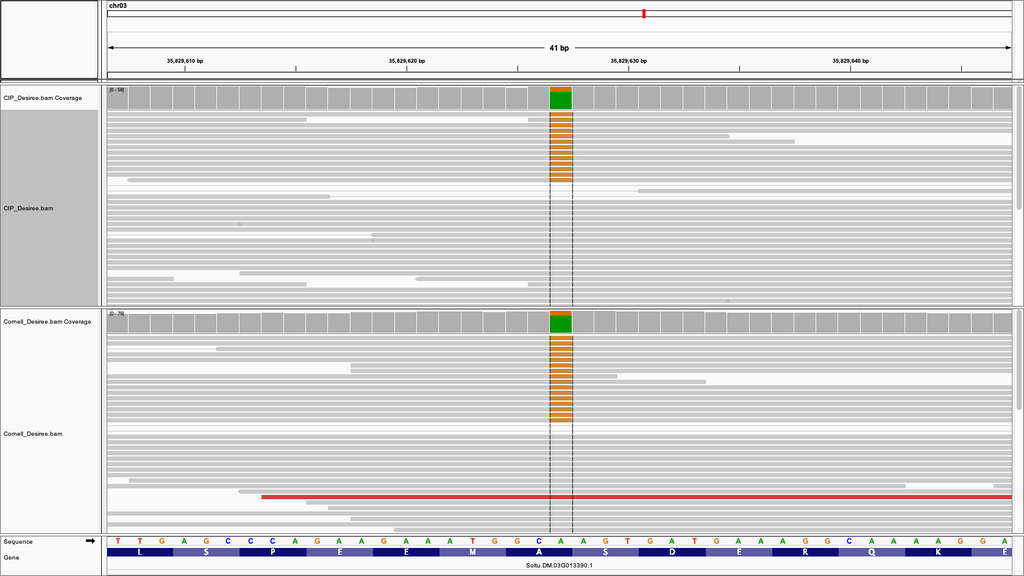

solcap_snp_c2_35358, chr03:35829627

> Here, euro allele A is the alternate allele and euro allele B is the reference allele

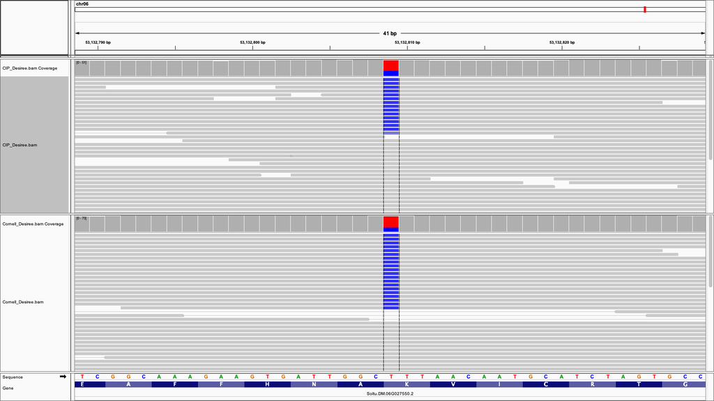

solcap_snp_c2_8660, chr06:53132809

> Here, euro allele A is the alternate allele and euro allele b is the reference allele

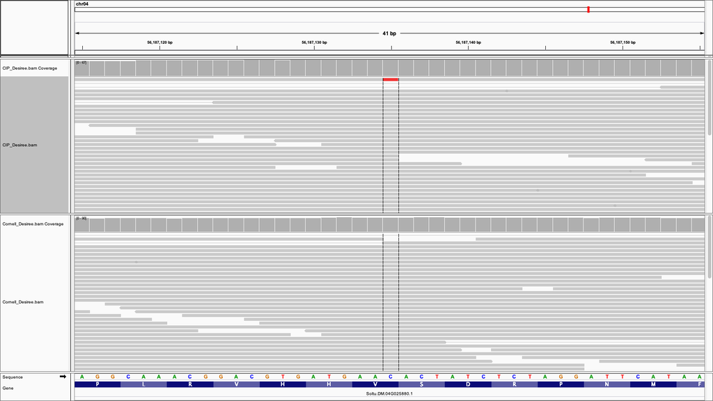

solcap_snp_c2_34957, chr04:56187135

> Here, A is the reference allele, B is the alternate allele.

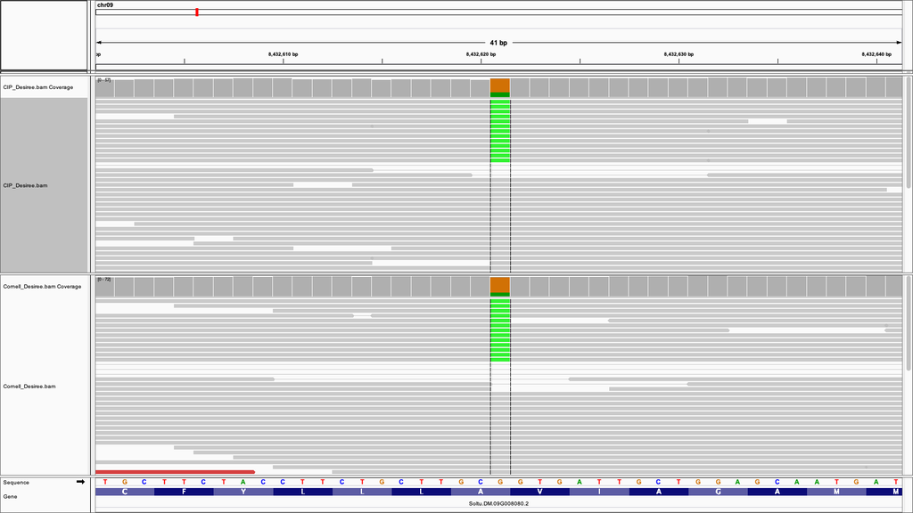

solcap_snp_c1_13785, chr09:8432621

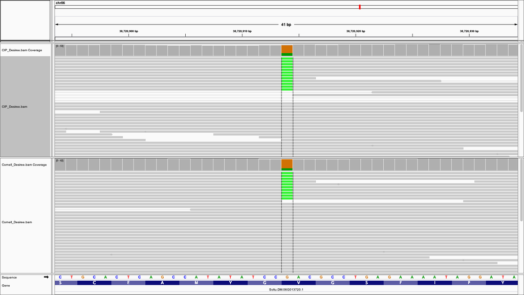

solcap_snp_c2_51765, chr06:38720914

> A and B seem to be arbitrary designations. How to determine which euro allele is A and which is B? Look in the Hirsch dataset for redundant genotypes.

## Explore Hirsch et al (2013) G3 dataset: SNP array genotyeps of 250 clones, primarily of North American origin, but with few European and landrace clones.

```r
solcap_snp <- read_excel("TableS4.xlsx", col_names = T, skip = 1, na = ".") %>%
  pivot_longer(-SNP, names_to = "Name", values_to = "genotype") %>%
  mutate(study = "solcap") %>%
  select(study, Name, everything())
head(solcap_snp)
```

| study | Name | SNP | genotype |
| --- | --- | --- | --- |
| solcap | A96104-2 | solcap_snp_c1_1 | TTTT |
| solcap | A97066-42 | solcap_snp_c1_1 | TCCC |
| solcap | AC Brador | solcap_snp_c1_1 | TCCC |
| solcap | ACL PI 175395 | solcap_snp_c1_1 | CCCC |
| solcap | ADG PI 195204 | solcap_snp_c1_1 | CCCC |
| solcap | Adirondack Blue | solcap_snp_c1_1 | TCCC |

Combine Sharma and Hirsch datasets:

```r
chip_snp <- euro_snp %>%
  filter(SNP %in% solcap_snp$SNP) %>%
  bind_rows(., solcap_snp) %>%
  pivot_wider(names_from = SNP, values_from = genotype) %>%
  arrange(Name)
head(chip_snp)
```

| study | Name | solcap_snp_c1_1 | solcap_snp_c1_1000 | solcap_snp_c1_10001 | solcap_snp_c1_10031 | solcap_snp_c1_10042 | solcap_snp_c1_10054 | solcap_snp_c1_10069 | solcap_snp_c1_10178 | solcap_snp_c1_10196 | solcap_snp_c1_10202 | solcap_snp_c1_10252 | solcap_snp_c1_10253 | solcap_snp_c1_10255 | solcap_snp_c1_10269 | solcap_snp_c1_1029 | solcap_snp_c1_10295 | solcap_snp_c1_10297 | solcap_snp_c1_10351 | solcap_snp_c1_10354 | solcap_snp_c1_10384 | solcap_snp_c1_10390 | solcap_snp_c1_10391 | solcap_snp_c1_10397 | solcap_snp_c1_10424 | solcap_snp_c1_10425 | solcap_snp_c1_10492 | solcap_snp_c1_10493 | solcap_snp_c1_10494 | … |
| --- | --- | --- | --- | --- | --- | --- | --- | --- | --- | --- | --- | --- | --- | --- | --- | --- | --- | --- | --- | --- | --- | --- | --- | --- | --- | --- | --- | --- | --- | --- |
| euro | 00C133-020 | AAAB | AAAA | AAAB | ABBB | AAAA | BBBB | AAAA | AAAB | AAAA | AAAB | BBBB | BBBB | AAAB | AAAA | NA | ABBB | BBBB | AAAA | BBBB | AABB | AAAA | AAAA | ABBB | AAAA | AAAB | AAAB | BBBB | ABBB | … |
| euro | 01C 071-002 | AAAA | BBBB | AAAB | ABBB | AAAA | BBBB | ABBB | AABB | AAAA | AAAA | ABBB | AABB | AAAB | AAAA | AABB | ABBB | AABB | AAAB | BBBB | BBBB | AAAA | AAAA | ABBB | AAAA | AAAA | AAAB | ABBB | AAAB | … |
| euro | 02C 053-016 | AAAA | AAAA | AABB | ABBB | ABBB | BBBB | ABBB | AABB | AAAA | AAAA | ABBB | AABB | AAAB | AAAA | ABBB | AABB | AABB | AAAA | BBBB | AAAB | AAAA | NA | BBBB | AAAA | AAAA | AABB | BBBB | AAAA | … |
| euro | 02M 012-001 | AAAB | AABB | AAAA | ABBB | AAAB | BBBB | AAAB | AAAB | AAAB | AAAB | ABBB | AAAB | AABB | AAAA | ABBB | ABBB | BBBB | AAAA | BBBB | AABB | AAAA | AABB | BBBB | AAAA | AAAB | AAAB | BBBB | AAAB | … |
| euro | 03M 016-002 | AAAB | ABBB | AABB | AABB | AABB | BBBB | BBBB | ABBB | AAAB | AAAB | BBBB | ABBB | AAAA | AAAA | ABBB | NA | BBBB | AAAA | BBBB | ABBB | AAAA | AAAA | BBBB | AAAB | AAAB | AAAA | ABBB | AAAB | … |
| euro | 03M 034-002 | AAAB | AABB | ABBB | ABBB | AAAB | BBBB | AAAA | NA | AAAA | AAAB | ABBB | ABBB | AAAB | AAAB | ABBB | ABBB | AAAB | AAAA | BBBB | ABBB | AAAA | AAAA | BBBB | AAAA | AAAA | NA | BBBB | AAAB | … |

How many clones are replicated in both panels?

```r
duplicates
```

```
 [1] "Atlantic"         "Bintje"           "Chieftain"        "Dark Red Norland" "Defender"         "Kennebec"         "Ranger Russet"    "Red Pontiac"      "Russet Burbank"   "Russet Norkotah"  "Sierra Gold"      "Spunta"           "Stirling"         "Superior"         "Torridon"         "Umatilla …
```

> Use simplex/triplex calls of these 16 clones to define alleles "A" and "B"

## Use genotype calls of redundant clones to define alleles "A" and "B" in the Sharma dataset:

```r
length(unique(define_alleles$SNP))
```

```
[1] 3343
```

> Here, each clone "votes" on the definition of alleles A and B. Here, 3,343 SNPs could be scored in this way. Do the clones agree with each other?

```r
length(unique(consensus_ab_definitions$SNP))
```

```
[1] 3221
```

> 3,221 SNPs remain.

```r
length(which(table(consensus_ab_definitions$SNP) == 1))
```

```
[1] 3037
```

```r
length(which(table(consensus_ab_definitions$SNP) > 1))
```

```
[1] 184
```

```r
length(which(table(consensus_ab_definitions$SNP) > 1)) / length(which(table(consensus_ab_definitions$SNP) >= 1))
```

```
[1] 0.05712512
```

> 3,037 SNPs remain. ~6% of SNPs do not have a unanimous definition of "A" and "B". To get an answer quickly, I'm going to run with the unanimous loci. Even a single discordant call results in exlcusion, so it may be possible to salvage more loci if needed. On the other hand, unanimous calls could be from only one clone.

```r
unanimous <- names(which(table(consensus_ab_definitions$SNP) == 1))
```

[output not shown]

> From here, make a distance matrix and a UPGMA tree using code from the SolCAP phylogeny scripts. As a sanity check, compare results with this convertd matrix with the european matrix on its own. Clusters should be the same.

## Combine SolCAP and euro panels:

```r
euro_for_join <- euro_recoded %>%
  select(-study)
head(euro_for_join)
```

| SNP | euro_allele_a | euro_allele_b | 00C133-020_euro | 01C 071-002_euro | 02C 053-016_euro | 02M 012-001_euro | 03M 016-002_euro | 03M 034-002_euro | 04C 055-004_euro | 04C 126-005_euro | 04M 034-013_euro | 05M 002-001_euro | 05M 004-003_euro | 05M 004-008_euro | 05M 012-004_euro | 06C 127-002_euro | 12288 AF 23_euro | 12601AB1_euro | 12636 A 2_euro | 15119 AC 5_euro | 1512C(16)_euro | 15144 A 3_euro | 1563C(14)_euro | 2070(54)_euro | 2182EF(7)_euro | 2424A(5)_euro | 3053-18_euro | 3681AD(1)_euro | 5008AB(6)_euro | … |
| --- | --- | --- | --- | --- | --- | --- | --- | --- | --- | --- | --- | --- | --- | --- | --- | --- | --- | --- | --- | --- | --- | --- | --- | --- | --- | --- | --- | --- | --- | --- |
| solcap_snp_c1_1 | C | T | CCCT | CCCC | CCCC | CCCT | CCCT | CCCT | CCCT | CCTT | CCTT | CCTT | CTTT | CTTT | CCCT | TTTT | CCCT | CCCT | CCCT | CCCC | CCCC | CCTT | CCTT | CCTT | CCCT | CCCT | CCCT | CCCT | CCCT | … |
| solcap_snp_c1_10031 | C | T | CTTT | CTTT | CTTT | CTTT | CCTT | CTTT | CTTT | CCTT | CTTT | CCCT | CCCT | CCTT | CTTT | CCCT | CCCT | CCCC | CCTT | CCTT | CCTT | CCCC | CCTT | CCCT | CCTT | CTTT | CCCT | TTTT | CTTT | … |
| solcap_snp_c1_10042 | C | T | CCCC | CCCC | CTTT | CCCT | CCTT | CCCT | CCCT | CCCC | CCCC | CCCC | CCCC | CCCC | CCCT | CCCC | CCCT | CCCC | CCCC | CCCT | CCTT | CTTT | CCCT | CCTT | CCCC | CCTT | CCCT | CCTT | CCCC | … |
| solcap_snp_c1_10054 | C | T | TTTT | TTTT | TTTT | TTTT | TTTT | TTTT | CTTT | CTTT | TTTT | CTTT | CTTT | CTTT | TTTT | CTTT | TTTT | CTTT | CTTT | TTTT | CTTT | CTTT | CTTT | TTTT | CTTT | CTTT | CTTT | CTTT | TTTT | … |
| solcap_snp_c1_10069 | G | A | GGGG | GAAA | GAAA | GGGA | AAAA | GGGG | GGAA | NA | NA | GAAA | GGAA | GGAA | GGAA | NA | GGAA | NA | GGAA | GGGA | GGAA | GGGA | AAAA | GAAA | GGAA | GAAA | GAAA | GGAA | GGAA | … |
| solcap_snp_c1_10178 | G | A | GGGA | GGAA | GGAA | GGGA | GAAA | NA | GGAA | GGAA | GGGA | GGGG | GAAA | GGAA | GAAA | GGAA | GGGA | GGAA | GAAA | GGGA | GGGA | GGGG | GGGG | GGGG | GGGG | GGGA | AAAA | GGAA | GGAA | … |

```r
solcap_for_join <- solcap_snp %>%
  rename(Sample = Name) %>%
  mutate(Sample = paste0(Sample, "_", study)) %>%
  pivot_wider(names_from = Sample, values_from = genotype) %>%
  select(-study)
head(solcap_for_join)
```

| SNP | A96104-2_solcap | A97066-42_solcap | AC Brador_solcap | ACL PI 175395_solcap | ADG PI 195204_solcap | Adirondack Blue_solcap | Adirondack Red_solcap | AF2291-10_solcap | AF2376-5_solcap | AF2574-1_solcap | All Blue_solcap | Allegany_solcap | Alpine Russet_solcap | Alturas_solcap | Andover_solcap | AO96141-3_solcap | AO96160-3_solcap | AO96164-1_solcap | AWN86514-2_solcap | B1829-5_solcap | Bannock Russet_solcap | Beacon Chipper_solcap | Belchip_solcap | Bintje_solcap | Blazer Russet_solcap | Boulder_solcap | Burbank_solcap | C297_solcap | C31-5-115_solcap | … |
| --- | --- | --- | --- | --- | --- | --- | --- | --- | --- | --- | --- | --- | --- | --- | --- | --- | --- | --- | --- | --- | --- | --- | --- | --- | --- | --- | --- | --- | --- | --- |
| solcap_snp_c1_1 | TTTT | TCCC | TCCC | CCCC | CCCC | TCCC | TCCC | TTTC | TTCC | CCCC | CCCC | TTCC | TTCC | TTTC | TTCC | CCCC | TTTC | TCCC | CCCC | TTCC | TCCC | TCCC | TCCC | TCCC | TTTC | TTCC | TTCC | CCCC | TCCC | … |
| solcap_snp_c1_1000 | TTCC | TCCC | TCCC | CCCC | TTTT | TCCC | TCCC | TTCC | CCCC | TTCC | TTCC | TTTC | TCCC | TTTC | NA | TTTT | TCCC | TTCC | TTTC | TTCC | TTCC | TTCC | NA | TCCC | TCCC | TTCC | NA | CCCC | TCCC | … |
| solcap_snp_c1_10001 | TTTA | TTAA | TTAA | AAAA | AAAA | TTAA | TAAA | TTAA | AAAA | AAAA | TTTT | TTAA | TTTT | TAAA | TTAA | TTTA | TTAA | TTAA | TAAA | AAAA | TTAA | TTTT | AAAA | TTAA | TTTA | TTAA | TTAA | TTAA | TTAA | … |
| solcap_snp_c1_10020 | CCCC | ACCC | CCCC | CCCC | CCCC | CCCC | CCCC | CCCC | CCCC | CCCC | CCCC | CCCC | CCCC | CCCC | CCCC | CCCC | CCCC | CCCC | ACCC | ACCC | CCCC | CCCC | CCCC | CCCC | CCCC | CCCC | CCCC | CCCC | CCCC | … |
| solcap_snp_c1_10031 | TTCC | TTTC | TTCC | TTCC | CCCC | TTTC | TCCC | TCCC | TTTC | TTCC | TCCC | TTTC | TTCC | TTCC | TTCC | TTTC | TTTC | TTTT | TTTC | TTTC | TTCC | TTCC | TTTC | TCCC | TTCC | TTTC | TTTC | TTTC | TTTC | … |
| solcap_snp_c1_10042 | TCCC | CCCC | TCCC | TTCC | CCCC | TCCC | CCCC | CCCC | CCCC | CCCC | CCCC | TTCC | TCCC | CCCC | TTTC | CCCC | TCCC | CCCC | TCCC | TCCC | CCCC | TTCC | TCCC | TCCC | CCCC | TCCC | TCCC | CCCC | CCCC | … |

```r
joined <- full_join(euro_for_join, solcap_for_join)
```

```r
joined_numeric_genos <- joined %>%
  mutate(across(matches("_euro$|_solcap$"), function(x) str_count(x, euro_allele_a))) %>%
  pivot_longer(matches("_euro$|_solcap$"), names_to = "Sample", values_to = "genotype") %>%
  select(-euro_allele_a, -euro_allele_b) %>%
  pivot_wider(names_from = SNP, values_from = genotype)
head(joined_numeric_genos)
```

| Sample | solcap_snp_c1_1 | solcap_snp_c1_10031 | solcap_snp_c1_10042 | solcap_snp_c1_10054 | solcap_snp_c1_10069 | solcap_snp_c1_10178 | solcap_snp_c1_10196 | solcap_snp_c1_10202 | solcap_snp_c1_10252 | solcap_snp_c1_10253 | solcap_snp_c1_10255 | solcap_snp_c1_10269 | solcap_snp_c1_1029 | solcap_snp_c1_10295 | solcap_snp_c1_10297 | solcap_snp_c1_10351 | solcap_snp_c1_10354 | solcap_snp_c1_10384 | solcap_snp_c1_10390 | solcap_snp_c1_10391 | solcap_snp_c1_10397 | solcap_snp_c1_10424 | solcap_snp_c1_10425 | solcap_snp_c1_10492 | solcap_snp_c1_10493 | solcap_snp_c1_10494 | solcap_snp_c1_10528 | solcap_snp_c1_1053 | solcap_snp_c1_10539 | … |
| --- | --- | --- | --- | --- | --- | --- | --- | --- | --- | --- | --- | --- | --- | --- | --- | --- | --- | --- | --- | --- | --- | --- | --- | --- | --- | --- | --- | --- | --- | --- |
| 00C133-020_euro | 3 | 1 | 4 | 0 | 4 | 3 | 4 | 3 | 0 | 0 | 3 | 4 | NA | 1 | 0 | 4 | 0 | 2 | 4 | 4 | 1 | 4 | 3 | 3 | 0 | 1 | 4 | 4 | 4 | … |
| 01C 071-002_euro | 4 | 1 | 4 | 0 | 1 | 2 | 4 | 4 | 1 | 2 | 3 | 4 | 2 | 1 | 2 | 3 | 0 | 0 | 4 | 4 | 1 | 4 | 4 | 3 | 1 | 3 | 2 | 4 | 2 | … |
| 02C 053-016_euro | 4 | 1 | 1 | 0 | 1 | 2 | 4 | 4 | 1 | 2 | 3 | 4 | 1 | 2 | 2 | 4 | 0 | 3 | 4 | NA | 0 | 4 | 4 | 2 | 0 | 4 | 4 | 2 | 4 | … |
| 02M 012-001_euro | 3 | 1 | 3 | 0 | 3 | 3 | 3 | 3 | 1 | 3 | 2 | 4 | 1 | 1 | 0 | 4 | 0 | 2 | 4 | 2 | 0 | 4 | 3 | 3 | 0 | 3 | 4 | 4 | 4 | … |
| 03M 016-002_euro | 3 | 2 | 2 | 0 | 0 | 1 | 3 | 3 | 0 | 1 | 4 | 4 | 1 | NA | 0 | 4 | 0 | 1 | 4 | 4 | 0 | 3 | 3 | 4 | 1 | 3 | 3 | 3 | 3 | … |
| 03M 034-002_euro | 3 | 1 | 3 | 0 | 4 | NA | 4 | 3 | 1 | 1 | 3 | 3 | 1 | 1 | 3 | 4 | 0 | 1 | 4 | 4 | 0 | 4 | 4 | NA | 0 | 3 | 3 | NA | 3 | … |

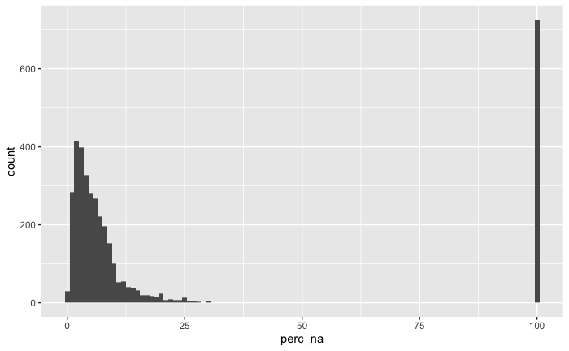

```r
missing3 <- apply(joined_numeric_genos, 2, function(x) length(which(is.na(x))) / length(x))
missing_df3 <- tibble(snp = names(missing3),
                      perc_na = 100 * missing3)
ggplot(missing_df3, aes(x = perc_na)) + geom_histogram(binwidth = 1)
```

```r
imputed3 <- joined_numeric_genos %>%
  select(-all_of(names(which(missing_df3$perc_na > 20)))) %>% # remove SNPs with > 20% missing data
  mutate(across(contains("snp"), function(x) replace_na(x, mean(x, na.rm = T)))) # impute missing data in the rest of the SNPs
head(imputed3)
```

| Sample | solcap_snp_c1_1 | solcap_snp_c1_10031 | solcap_snp_c1_10042 | solcap_snp_c1_10054 | solcap_snp_c1_10069 | solcap_snp_c1_10178 | solcap_snp_c1_10196 | solcap_snp_c1_10202 | solcap_snp_c1_10252 | solcap_snp_c1_10253 | solcap_snp_c1_10255 | solcap_snp_c1_10269 | solcap_snp_c1_1029 | solcap_snp_c1_10295 | solcap_snp_c1_10297 | solcap_snp_c1_10351 | solcap_snp_c1_10354 | solcap_snp_c1_10384 | solcap_snp_c1_10390 | solcap_snp_c1_10391 | solcap_snp_c1_10397 | solcap_snp_c1_10424 | solcap_snp_c1_10425 | solcap_snp_c1_10492 | solcap_snp_c1_10493 | solcap_snp_c1_10494 | solcap_snp_c1_10528 | solcap_snp_c1_1053 | solcap_snp_c1_10539 | … |
| --- | --- | --- | --- | --- | --- | --- | --- | --- | --- | --- | --- | --- | --- | --- | --- | --- | --- | --- | --- | --- | --- | --- | --- | --- | --- | --- | --- | --- | --- | --- |
| 00C133-020_euro | 3 | 1 | 4 | 0 | 4 | 3.000000 | 4 | 3 | 0 | 0 | 3 | 4 | 1.16458 | 1.0000000 | 0 | 4 | 0 | 2 | 4 | 4.000000 | 1 | 4 | 3 | 3.000000 | 0 | 1 | 4 | 4.000000 | 4 | … |
| 01C 071-002_euro | 4 | 1 | 4 | 0 | 1 | 2.000000 | 4 | 4 | 1 | 2 | 3 | 4 | 2.00000 | 1.0000000 | 2 | 3 | 0 | 0 | 4 | 4.000000 | 1 | 4 | 4 | 3.000000 | 1 | 3 | 2 | 4.000000 | 2 | … |
| 02C 053-016_euro | 4 | 1 | 1 | 0 | 1 | 2.000000 | 4 | 4 | 1 | 2 | 3 | 4 | 1.00000 | 2.0000000 | 2 | 4 | 0 | 3 | 4 | 3.031308 | 0 | 4 | 4 | 2.000000 | 0 | 4 | 4 | 2.000000 | 4 | … |
| 02M 012-001_euro | 3 | 1 | 3 | 0 | 3 | 3.000000 | 3 | 3 | 1 | 3 | 2 | 4 | 1.00000 | 1.0000000 | 0 | 4 | 0 | 2 | 4 | 2.000000 | 0 | 4 | 3 | 3.000000 | 0 | 3 | 4 | 4.000000 | 4 | … |
| 03M 016-002_euro | 3 | 2 | 2 | 0 | 0 | 1.000000 | 3 | 3 | 0 | 1 | 4 | 4 | 1.00000 | 0.9005629 | 0 | 4 | 0 | 1 | 4 | 4.000000 | 0 | 3 | 3 | 4.000000 | 1 | 3 | 3 | 3.000000 | 3 | … |
| 03M 034-002_euro | 3 | 1 | 3 | 0 | 4 | 2.725599 | 4 | 3 | 1 | 1 | 3 | 3 | 1.00000 | 1.0000000 | 3 | 4 | 0 | 1 | 4 | 4.000000 | 0 | 4 | 4 | 2.758929 | 0 | 3 | 3 | 3.255732 | 3 | … |

Pairwise distances:

```r
dist_mtx3 <- imputed3 %>%
  dplyr::select(-Sample) %>%
  dist(method = "euclidean") %>%
  as.matrix()
rownames(dist_mtx3) <- imputed3$Sample
colnames(dist_mtx3) <- imputed3$Sample
```

UPGMA and NJ trees from distance matrices:

```r
UPGMA_tetra <- upgma(dist_mtx3)
nj_tetra <- NJ(dist_mtx3)
```

Write trees to disk:

```r
write.tree(UPGMA_tetra, file = "solcap_euro_combined_UPGMA_2021_0301.tre")
write.tree(nj_tetra, file = "solcap_euro_combined_NJ_2021_0301.tre")
```

> Are the duplicated samples next to each other?

| Clone | Duplicates neighbors | Reason |
| --- | --- | --- |
| Atlantic | Yes |  |
| Bintje | Yes |  |
| Chieftain | Yes |  |
| Dark Red Norland | Yes |  |
| Defender | Yes |  |
| Kennebec | Yes |  |
| Ranger Russet | Yes |  |
| Red Pontiac | Yes |  |
| Russet Burbank | Yes |  |
| Russet Norkotah | Yes |  |
| Sierra Gold | Yes |  |
| Spunta | Yes |  |
| Stirling | Yes |  |
| Superior | Yes |  |
| Torridon | Yes |  |
| Umatilla Russet | No | Looks like Vales Russet clone |

Note: Desiree has no close matches to SolCAP panel, is surrounded by european cultivars.

## What is Desiree? Combine sequence-based genotypes with chip-based genotypes and rerun the phylogeny:

```r
# get v6 coordinates of SNPs in the combined matrix
gff_cols <- c("seqid", "source", "type", "start", "end", "score", "strand", "phase", "gff_attributes")

solcap_v6_coords <- read_tsv("potato_array_SNPs_v6_liftover.gff3",
                             col_names = gff_cols,
                             comment = "#")
head(solcap_v6_coords)
```

```r
length(unique(euro_snp$SNP))
length(unique(solcap_snp$SNP))

left_join(solcap_snp, euro_snp, by = c("study", "Name", "SNP", "genotype")) %>%
  group_by(SNP) %>%
  tally() %>%
  nrow()

solcap_snp %>%
  filter(SNP %in% solcap_v6_coords$attributes) %>%
  group_by(SNP) %>%
  tally() %>%
  nrow()

euro_snp %>%
  filter(SNP %in% solcap_v6_coords$attributes) %>%
  group_by(SNP) %>%
  tally() %>%
  nrow()

nrow(euro_recoded)

euro_recoded %>%
  filter(SNP %in% solcap_v6_coords$attributes) %>%
  nrow()

euro_recoded %>%
  filter(SNP %in% solcap_v6_ext$id) %>%
  nrow
```

[output not shown]

> Summary of European panel SNPs: * 5,718 in the original dataset. * 4,455 could be anchored to v6. * 3,037 european panel SNPs could be recoded based on the SolCAP genotype calls. * 2,387 recoded european SNPs could be anchored to v6 (required for intersection with sequence-based calls). * 2,032 recoded european SNPs could be anchored to v6 using Buell lab annotation.

> Summary of SolCAP panel SNPs: * 3,763 in the original dataset. * 3,763 could be anchored to v6.

Write out recoded SNPs to GFF file, then use to interesect sequence-based genotypes

```r
filter(solcap_v6_coords, attributes %in% euro_recoded$SNP) %>%
  arrange(seqid, start, end) %>%
  write_tsv("solcap_v6_snp_for_euro_phylo.gff", col_names = F)
```

## On server, intersect variant calls with recoded SNPs, decompose calls to allelic primitives, then annotate intersecting SNP:

```
#!/bin/bash
cd /cato2pool/backup-share/kramundson/cerveza/data/calls
conda activate oak
bedtools intersect -sorted -header -a chr01-calls.vcf.gz -b solcap_v6_for_euro_phylo.gff > all-calls-euro-phylo.vcf
for i in chr{02..12}-calls.vcf.gz
do
  bedtools intersect -sorted -a $i -b solcap_v6_for_euro_phylo.gff >> all-calls-euro-phylo.vcf
done

gzip all-calls-euro-phylo.vcf
vcfallelicprimitives -g all-calls-euro-phylo.vcf | gzip > split-mnp-calls-euro-phylo.vcf.gz
bedtools intersect -header -a split-mnp-calls-euro-phylo.vcf.gz -b solcap_v6_for_euro_phylo.gff -wb | gzip > wb-split-calls-euro-phylo.vcf.gz
```

## Add individuals with sequence-based SNP calls to SNP matrix, then remake tree:

```r
file <- "wb-split-calls-euro-phylo.vcf.gz"
vcf_header <- system(paste0("zgrep '^#C' ", file), intern = T) %>%
  str_remove("^#") %>%
  str_split(pattern = "\t") %>%
  pluck(1)
vcf_header
```

```r
vcf <- read_tsv(file, comment = "#", col_names = c(vcf_header, gff_cols),  na = c(".", "./.", "././.", "./././.", "NA"))
```

```r
# not needed here
# info  <- str_split(vcf$INFO[1], ";")[[1]] %>%
#   str_replace("=.+", "")
# info
```

```r
table(vcf$FORMAT)
```

```r
attributes <- str_split(names(table(vcf$FORMAT)), ":", simplify = F) %>% pluck(1)
attributes
```

```r
biallelic_series <- c("0/0/0/0", "0/0/0/1", "0/0/1/1", "0/1/1/1", "1/1/1/1",
                      "0|0|0|0", "0|0|0|1", "0|0|1|1", "0|1|1|1", "1|1|1|1")
```

```r
sample_vars <- colnames(vcf)[10:(ncol(vcf)-length(gff_cols))]
```

```r
vcf2 <- vcf %>%
  # mutate(INFO = str_replace_all(INFO, "[A-Za-z]*=", "")) %>%
  # separate(INFO, into = info, sep = ";", convert = T) %>%
  Reduce(f = sep, x = sample_vars)
```

```r
vcf3 <- vcf2 %>%
  select(CHROM, POS, REF, ALT, all_of(gff_cols), everything(), -contains("KPT"),) %>%
  filter(USDA_Desiree_GT %in% biallelic_series)
```

```r
vcf4 <- vcf3 %>%
  filter(CIP_Desiree_GT %in% biallelic_series) %>%
  filter(Cornell_Desiree_GT %in% biallelic_series) %>%
  filter(CNRS_Desiree_GT %in% biallelic_series) %>%
  rename(SNP = gff_attributes)
nrow(vcf4)
```

join seq genotypes to chip genotypes before they're numeric

```r
chip_and_seq <- left_join(vcf4, joined, by="SNP")
```

reverse complement SNP chip calls if chip DM call doesn't match the VCF REF allele:

```r
rc_corrected <- chip_and_seq %>%
  filter(str_length(REF) == 1) %>%
  filter(str_length(ALT) == 1) %>%
  distinct() %>%
  mutate(revcomp_chip = !str_starts(`DM1-3 516 R44_solcap`, REF)) %>%
  mutate(across(matches("_solcap$|_euro$"), function(x) ifelse(revcomp_chip, chartr("ACGT", "TGCA", x), x))) %>% # reverse only
  select(CHROM, POS, REF, ALT, SNP, revcomp_chip, everything())
```

numeric SNPs:

```r
numeric_genos <- rc_corrected %>%
  mutate(across(ends_with("GT"), function(x) str_count(x, "0"))) %>%
  mutate(across(matches("_solcap$|_euro$"), function(x) str_count(x, REF))) %>%
  select(SNP, matches("GT$|solcap$|euro$")) %>%
  pivot_longer(-SNP, names_to = "Sample", values_to = "geno") %>%
  pivot_wider(names_from = SNP, values_from = geno)
```

impute missing data:

```r
imputed <- numeric_genos %>%
  # select(-all_of(names(which(missing_df3$perc_na > 20)))) %>% # remove SNPs with > 20% missing data
  mutate(across(contains("snp"), function(x) replace_na(x, mean(x, na.rm = T)))) # impute missing data in the rest of the SNPs
dim(imputed)
```

```r
imputed %>%
  filter(grepl("euro", Sample)) %>%
  nrow
```

```r
dist_mtx <- imputed %>%
  dplyr::select(-Sample) %>%
  dist(method = "euclidean") %>%
  as.matrix()
rownames(dist_mtx) <- imputed$Sample
colnames(dist_mtx) <- imputed$Sample
```

UPGMA and NJ trees from distance matrices:

```r
UPGMA <- upgma(dist_mtx)
nj <- NJ(dist_mtx)
```

Write trees to disk:

```r
write.tree(UPGMA, file = "solcap_euro_seq_UPGMA_2021_0301.tre")
write.tree(nj, file = "solcap_euro_seq_NJ_2021_0301.tre")
```

## Follow up actions:

1. Email MSU to see whether Urgenta or Depesche are in their SNP database. Done.
2. Request genomic DNA of Urgenta or Depesche from European gemrplasm database. Depesche gDNA requested.
3. Request Depesche and/or Urgenta cuttings from Sturgeon Bay. Urgenta ordered - Depesche not available.